# Coursera Practical Machine Learning Course Project

Bob Currie

December 31, 2017

## Prediction Assignment

### Introduction

The data used for this project was obtained from the study *“Qualitative Activity Recognition of Weight Lifting Exercises”* (Velleso, et al, 2013). The study used sensors to obtain measurements from six different participants as they correctly and incorrectly performed sets of dumbbell curls.

Participants each performed a set of 10 repetitions of dumbbell biceps curls, according to the following specifications (as supervised by an experienced weight lifter).

| Class | Exercise Specification |
| --- | --- |
| A | Correctly performed |
| B | Throwing the elbows to the front |
| C | Lifting the dumbbell only halfway |
| D | Lowering the dumbbell only halfway |
| E | Throwing the hips to the front |

Sensors were attached to the participants’ gloves(**forearm**), **arm**, **belt**, and to the **dumbbell** itself. The readings from the sensors were collected using a sliding window approach with different lengths from 0.5 to 2.5 seconds, with a 0.5 second overlap. Measurements taken included 3-axis (x, y and z) accelerometer, gyroscope, and magnetometer readings, as well as Euler angles (roll, pitch and yaw) from each sensor. In addition, eight additional features were calculated for for each Euler angle; mean, variance, standard deviation, maximum, minimum, amplitude, kurtosis, and skewness (generating in total 96 derived feature sets).

The objective of this project is two-fold:

1. To develop a mutli-classification machine learning model (using the training dataset) to enable us to accurately predict the class of each exercise.
2. To use this model to predict the class of the observations in the provided testing dataset and submit these predictions for course grading.

### Data Loading, Tidying, and Feature Selection

The first step is to download the datasets from the web and read them into R dataframes

Note: There are two files associated with this project, “pml-training.csv” and “pml-testing.csv”. It is important to note that “pml-testing” is used ONLY for the Prediction Quiz portion. The “pml-training” dataset will be read into an R dataframe (**qarwle**), then split into two datafames; **training** (for developing and training the model), and **testing** (for measuring out of sample model error and accuracy).

```r
## Download files from web
linkTraining <- "https://d396qusza40orc.cloudfront.net/predmachlearn/pml-training.csv"
linkTesting <- "https://d396qusza40orc.cloudfront.net/predmachlearn/pml-testing.csv"

# Download to working directory
download.file(url = linkTraining, destfile = "pml-training.csv")
download.file(url = linkTesting, destfile = "pml-testing.csv")

qarwle <- read.csv("pml-training.csv", header = TRUE, stringsAsFactors = FALSE)
quiz_testing <- read.csv("pml-testing.csv", header = TRUE, stringsAsFactors = FALSE)

dim(qarwle); dim(quiz_testing)
```

```
[1] 19622   160
```

```
[1]  20 160
```

```r
str(qarwle)
```

```
'data.frame':   19622 obs. of  160 variables:
 $ X                       : int  1 2 3 4 5 6 7 8 9 10 ...
 $ user_name               : chr  "carlitos" "carlitos" "carlitos" "carlitos" ...
 $ raw_timestamp_part_1    : int  1323084231 1323084231 1323084231 1323084232 1323084232 1323084232 1323084232 1323084232 1323084232 1323084232 ...
 $ raw_timestamp_part_2    : int  788290 808298 820366 120339 196328 304277 368296 440390 484323 484434 ...
 $ cvtd_timestamp          : chr  "05/12/2011 11:23" "05/12/2011 11:23" "05/12/2011 11:23" "05/12/2011 11:23" ...
 $ new_window              : chr  "no" "no" "no" "no" ...
 $ num_window              : int  11 11 11 12 12 12 12 12 12 12 ...
 $ roll_belt               : num  1.41 1.41 1.42 1.48 1.48 1.45 1.42 1.42 1.43 1.45 ...
 $ pitch_belt              : num  8.07 8.07 8.07 8.05 8.07 8.06 8.09 8.13 8.16 8.17 ...
 $ yaw_belt                : num  -94.4 -94.4 -94.4 -94.4 -94.4 -94.4 -94.4 -94.4 -94.4 -94.4 ...
 $ total_accel_belt        : int  3 3 3 3 3 3 3 3 3 3 ...
 $ kurtosis_roll_belt      : chr  "" "" "" "" ...
 $ kurtosis_picth_belt     : chr  "" "" "" "" ...
 $ kurtosis_yaw_belt       : chr  "" "" "" "" ...
```

[output cut: 86 more lines]

#### Data Tidying

We see from looking at the structure of the dataframe that there are several features that either have empty (character) data or missing (NA) data. We will deal with those variables in a moment.

First, let’s convert the classe variable into a factor, and also convert all other features into numeric variables

```r
class(qarwle$classe)
```

```
[1] "character"
```

```r
qarwle$classe <- as.factor(qarwle$classe)
qarwle$user_name <- as.factor(qarwle$user_name)

for (i in c(8:159)) {
    qarwle[,i] <- as.numeric(qarwle[,i])
}
```

Let’s briefly summarize our dataframe:

```r
table(qarwle$classe)
```

```
   A    B    C    D    E
5580 3797 3422 3216 3607
```

```r
table(qarwle$user_name, qarwle$classe)
```

```
              A    B    C    D    E
  adelmo   1165  776  750  515  686
  carlitos  834  690  493  486  609
  charles   899  745  539  642  711
  eurico    865  592  489  582  542
  jeremy   1177  489  652  522  562
  pedro     640  505  499  469  497
```

#### Feature Selection

We see from looking at the dataframe that the derived features are not calculated for every observation. As a matter of fact, they are only calculated for each new window (records where new_window = “yes”). Let’s look at only the “avg”" derived variables for the belt features as a demonstration.

```r
## new window is "yes", we see the derived features
head(qarwle[qarwle$new_window == "yes", c(28, 31, 34)],20)
```

```
    avg_roll_belt avg_pitch_belt avg_yaw_belt
24            1.5            8.1        -94.4
52            1.4            7.9        -94.3
76            1.2            7.4        -94.1
165           1.0            7.1        -93.8
210         128.9           28.1          1.7
241         128.9           27.9          2.3
314         126.2           27.4          0.1
401         124.8           25.7         -1.4
463         123.6           26.0         -2.3
476         123.3           26.3         -3.2
506         123.7           26.2         -3.3
532         124.0           26.4         -3.1
552         123.9           25.8         -2.2
581         122.3           26.0         -3.5
598         122.5           25.9         -4.2
645         123.0           26.1         -3.7
749         127.6          -41.5        172.2
772         129.8          -39.9        166.4
832         129.0          -40.4        163.0
872         129.5          -39.8        161.0
```

```r
## new window is "no", there aren't any derived features
head(qarwle[qarwle$new_window == "no", c(28, 31, 34)],20)
```

```
   avg_roll_belt avg_pitch_belt avg_yaw_belt
1             NA             NA           NA
2             NA             NA           NA
3             NA             NA           NA
4             NA             NA           NA
5             NA             NA           NA
6             NA             NA           NA
7             NA             NA           NA
8             NA             NA           NA
9             NA             NA           NA
10            NA             NA           NA
11            NA             NA           NA
12            NA             NA           NA
13            NA             NA           NA
14            NA             NA           NA
15            NA             NA           NA
16            NA             NA           NA
17            NA             NA           NA
18            NA             NA           NA
19            NA             NA           NA
20            NA             NA           NA
```

Rather than impute these features for the observations with missing variables, we will remove them from the dataset used to develop the model. This has the added benefit of removing features that we assume will be highly correlated with existing features.

```r
remove <- c("kurtosis", "skewness", "max", "min", "amplitude", "var", "avg", "stddev")

qarwle <- qarwle[-grep(paste(remove, collapse = "|"), names(qarwle))]

dim(qarwle); names(qarwle)
```

```
[1] 19622    60
```

```
 [1] "X"                    "user_name"            "raw_timestamp_part_1"
 [4] "raw_timestamp_part_2" "cvtd_timestamp"       "new_window"
 [7] "num_window"           "roll_belt"            "pitch_belt"
[10] "yaw_belt"             "total_accel_belt"     "gyros_belt_x"
[13] "gyros_belt_y"         "gyros_belt_z"         "accel_belt_x"
[16] "accel_belt_y"         "accel_belt_z"         "magnet_belt_x"
[19] "magnet_belt_y"        "magnet_belt_z"        "roll_arm"
[22] "pitch_arm"            "yaw_arm"              "total_accel_arm"
[25] "gyros_arm_x"          "gyros_arm_y"          "gyros_arm_z"
[28] "accel_arm_x"          "accel_arm_y"          "accel_arm_z"
[31] "magnet_arm_x"         "magnet_arm_y"         "magnet_arm_z"
[34] "roll_dumbbell"        "pitch_dumbbell"       "yaw_dumbbell"
[37] "total_accel_dumbbell" "gyros_dumbbell_x"     "gyros_dumbbell_y"
[40] "gyros_dumbbell_z"     "accel_dumbbell_x"     "accel_dumbbell_y"
[43] "accel_dumbbell_z"     "magnet_dumbbell_x"    "magnet_dumbbell_y"
[46] "magnet_dumbbell_z"    "roll_forearm"         "pitch_forearm"
[49] "yaw_forearm"          "total_accel_forearm"  "gyros_forearm_x"
[52] "gyros_forearm_y"      "gyros_forearm_z"      "accel_forearm_x"
[55] "accel_forearm_y"      "accel_forearm_z"      "magnet_forearm_x"
[58] "magnet_forearm_y"     "magnet_forearm_z"     "classe"
```

We can also remove the first seven features of the dataset, as they contain info such as user_name, timestamp and window data, which are not relevant

```r
qarwle <- qarwle[,-c(1:7)]
```

### Model Development

We will use the tools in the R ‘caret’ package to develop a model

First, let’s use cross-validation by breaking the qarwle dataframe into training and testing dataframes.

```r
# split dataframe into training (75% of obs) and testing (25%) data sets
inTraining <- createDataPartition(qarwle$classe, p = .75, list = FALSE)
training <- qarwle[inTraining,]
testing <- qarwle[-inTraining,]

dim(training); dim(testing)
```

```
[1] 14718    53
```

```
[1] 4904   53
```

```r
# Use x / y syntax
x <- training[, -53]
y <- training[, 53]
```

Let’s now develop the model. We will develop a “random forest” model using the caret’s package train function.

NOTE: Please see [Improving Performance of Random Forest in caret::train()](https://github.com/lgreski/datasciencectacontent/blob/master/markdown/pml-randomForestPerformance.md)

```r
#configure trainControl object
rfModelControl <- trainControl(method = "cv",
                           number = 5,
                           allowParallel = TRUE)

#configure parallel processing
cluster <- makeCluster(detectCores() - 1) # leave 1 core for OS
registerDoParallel(cluster)

#develop training model
system.time(rfModel <- train(x, y, method = "rf", data = qarwle, trControl = rfModelControl))
```

```
   user  system elapsed
  72.16    3.17  728.98
```

```r
#stop the cluster and return R to single threaded processing
stopCluster(cluster)
registerDoSEQ()
```

### Results

```r
rfModel
```

```
Random Forest

14718 samples
   52 predictor
    5 classes: 'A', 'B', 'C', 'D', 'E'

No pre-processing
Resampling: Cross-Validated (5 fold)
Summary of sample sizes: 11775, 11775, 11774, 11773, 11775
Resampling results across tuning parameters:

  mtry  Accuracy   Kappa
   2    0.9923226  0.9902876
  27    0.9915752  0.9893426
  52    0.9877706  0.9845295

Accuracy was used to select the optimal model using  the largest value.
The final value used for the model was mtry = 2.
```

```r
confusionMatrix.train(rfModel)
```

```
Cross-Validated (5 fold) Confusion Matrix

(entries are percentual average cell counts across resamples)

          Reference
Prediction    A    B    C    D    E
         A 28.4  0.1  0.0  0.0  0.0
         B  0.0 19.2  0.2  0.0  0.0
         C  0.0  0.0 17.3  0.3  0.0
         D  0.0  0.0  0.0 16.0  0.0
         E  0.0  0.0  0.0  0.0 18.3

 Accuracy (average) : 0.9923
```

```r
varImp(rfModel, scale = FALSE)
```

```
rf variable importance

  only 20 most important variables shown (out of 52)

                     Overall
roll_belt              535.3
yaw_belt               463.2
magnet_dumbbell_z      403.9
pitch_belt             387.0
magnet_dumbbell_y      376.1
pitch_forearm          362.3
roll_forearm           330.0
magnet_dumbbell_x      326.0
magnet_belt_y          295.5
accel_dumbbell_y       288.9
magnet_belt_z          288.2
accel_belt_z           286.3
roll_dumbbell          286.3
accel_dumbbell_z       259.5
roll_arm               249.3
accel_forearm_x        242.3
gyros_belt_z           228.6
accel_dumbbell_x       227.8
yaw_dumbbell           225.9
total_accel_dumbbell   222.7
```

```r
predictors(rfModel)
```

```
 [1] "roll_belt"            "pitch_belt"           "yaw_belt"
 [4] "total_accel_belt"     "gyros_belt_x"         "gyros_belt_y"
 [7] "gyros_belt_z"         "accel_belt_x"         "accel_belt_y"
[10] "accel_belt_z"         "magnet_belt_x"        "magnet_belt_y"
[13] "magnet_belt_z"        "roll_arm"             "pitch_arm"
[16] "yaw_arm"              "total_accel_arm"      "gyros_arm_x"
[19] "gyros_arm_y"          "gyros_arm_z"          "accel_arm_x"
[22] "accel_arm_y"          "accel_arm_z"          "magnet_arm_x"
[25] "magnet_arm_y"         "magnet_arm_z"         "roll_dumbbell"
[28] "pitch_dumbbell"       "yaw_dumbbell"         "total_accel_dumbbell"
[31] "gyros_dumbbell_x"     "gyros_dumbbell_y"     "gyros_dumbbell_z"
[34] "accel_dumbbell_x"     "accel_dumbbell_y"     "accel_dumbbell_z"
[37] "magnet_dumbbell_x"    "magnet_dumbbell_y"    "magnet_dumbbell_z"
[40] "roll_forearm"         "pitch_forearm"        "yaw_forearm"
[43] "total_accel_forearm"  "gyros_forearm_x"      "gyros_forearm_y"
[46] "gyros_forearm_z"      "accel_forearm_x"      "accel_forearm_y"
[49] "accel_forearm_z"      "magnet_forearm_x"     "magnet_forearm_y"
[52] "magnet_forearm_z"
```

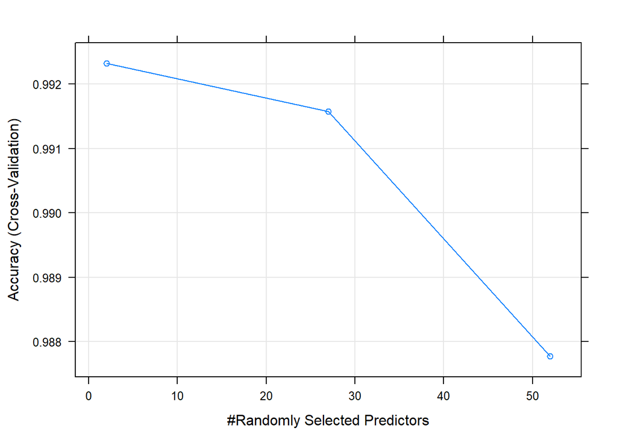

```r
plot(rfModel)
```

```r
#predict using testing data set
rfPredictions <- predict(rfModel, testing)
confusionMatrix(rfPredictions, testing$classe)
```

```
Confusion Matrix and Statistics

          Reference
Prediction    A    B    C    D    E
         A 1395    2    0    0    0
         B    0  947    1    0    0
         C    0    0  854    0    0
         D    0    0    0  803    1
         E    0    0    0    1  900

Overall Statistics

               Accuracy : 0.999
                 95% CI : (0.9976, 0.9997)
    No Information Rate : 0.2845
    P-Value [Acc > NIR] : < 2.2e-16

                  Kappa : 0.9987
 Mcnemar's Test P-Value : NA

Statistics by Class:

                     Class: A Class: B Class: C Class: D Class: E
Sensitivity            1.0000   0.9979   0.9988   0.9988   0.9989
Specificity            0.9994   0.9997   1.0000   0.9998   0.9998
Pos Pred Value         0.9986   0.9989   1.0000   0.9988   0.9989
Neg Pred Value         1.0000   0.9995   0.9998   0.9998   0.9998
Prevalence             0.2845   0.1935   0.1743   0.1639   0.1837
Detection Rate         0.2845   0.1931   0.1741   0.1637   0.1835
Detection Prevalence   0.2849   0.1933   0.1741   0.1639   0.1837
Balanced Accuracy      0.9997   0.9988   0.9994   0.9993   0.9993
```

```r
# Quiz
finalPredict <- predict(rfModel, quiz_testing)
finalPredict
```

```
 [1] B A B A A E D B A A B C B A E E A B B B
Levels: A B C D E
```